# R语言-拍拍贷数据探索性分析

### 6.5. 非首标历史成功借款金额和借款利率与借款类型的关系

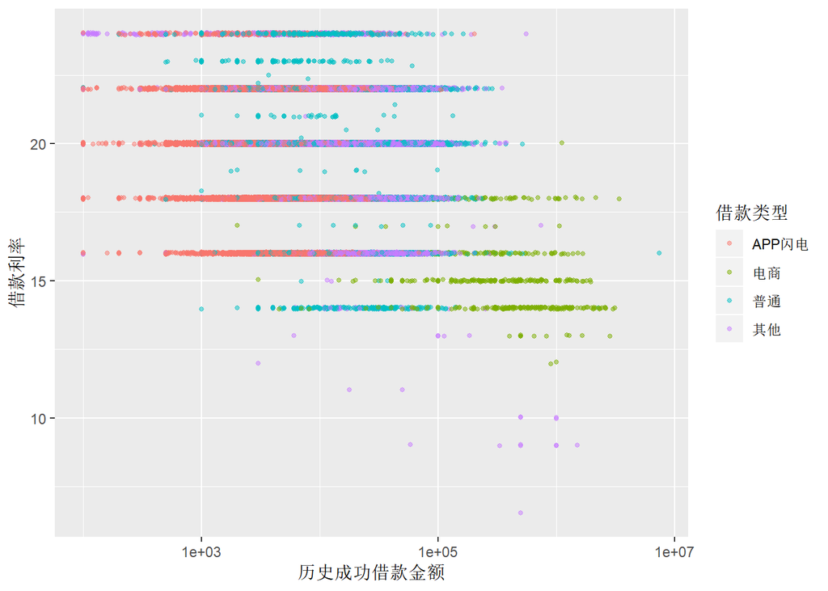

结论：App闪电历史成功借款金额较少，借款利率也较高；电商历史成功借款金额较多，利率也较低；普通与其他历史成功借款金额介于APP闪电和电商之间，利率分布比较广泛。

### 6.6. 非首标历史成功借款金额和借款利率与初始评级的关系

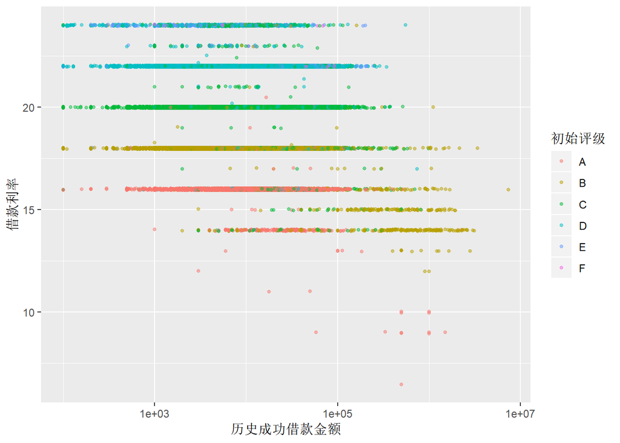

结论：初始评级与历史成功借款金额无明显关系；初始评级越高，借款利率越低。

### 6.7. 非首标历史正常还款期数和借款利率与借款类型的关系

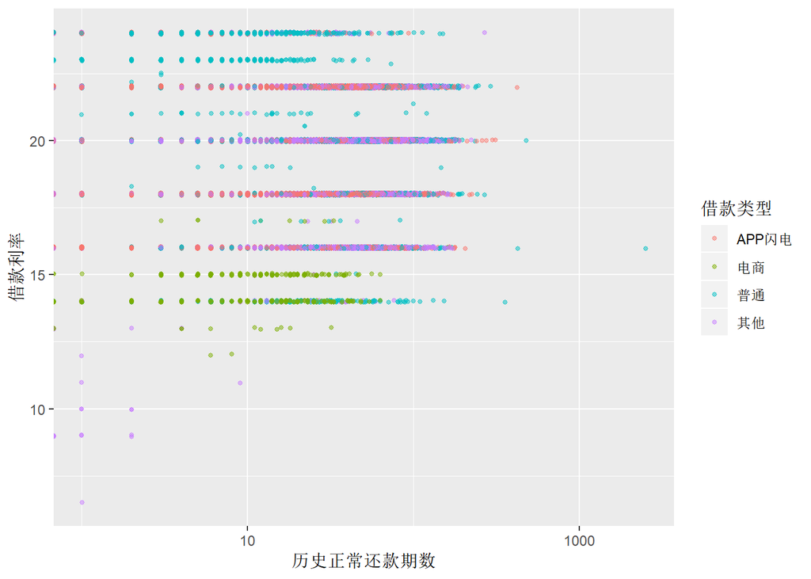

结论：历史正常还款期数与借款类型无明显关系；电商借款利率较低。

### 6.8. 非首标历史正常还款期数和借款利率与初始评级的关系

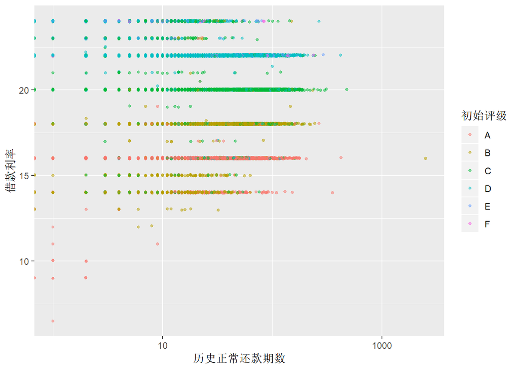

结论：历史正常还款期数与初始评级无明显关系；初始评级越高，利率越低。

### 6.9. 历史成功借款金额和借款金额与借款类型的关系

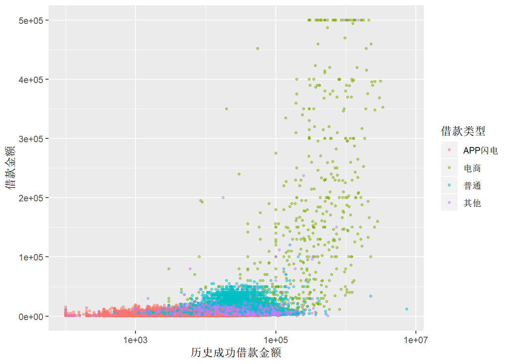

结论：历史成功借款金额越多，则借款金额也越多。不同借款类型的历史成功借款金额和借款金额由高到底分别是电商，普通，其他，APP闪电。

## 创建线性模型

### 1.首标模型

```
##
## Calls:
## m1: lm(formula = I(借款利率) ~ I(初始评级), data = lc_first)
## m2: lm(formula = I(借款利率) ~ I(初始评级) + 借款金额, data = lc_first)
## m3: lm(formula = I(借款利率) ~ I(初始评级) + 借款金额 + 借款类型,
##     data = lc_first)
##
## ==========================================================================
##                                 m1              m2              m3
## --------------------------------------------------------------------------
##   (Intercept)                  15.542***       15.687***       15.752***
##                                (0.022)         (0.022)         (0.022)
##   I(初始评级): B/A              2.375***        2.350***        2.295***
##                                (0.024)         (0.024)         (0.023)
##   I(初始评级): C/A              4.508***        4.433***        4.368***
##                                (0.024)         (0.023)         (0.023)
##   I(初始评级): D/A              6.444***        6.365***        6.303***
##                                (0.022)         (0.022)         (0.022)
##   I(初始评级): E/A              7.889***        7.792***        7.884***
##                                (0.024)         (0.024)         (0.023)
##   I(初始评级): F/A              5.718***        5.610***        5.673***
##                                (0.045)         (0.044)         (0.043)
##   借款金额                                     -0.000***       -0.000***
##                                                (0.000)         (0.000)
##   借款类型: 电商/APP闪电                                       -2.094***
##                                                                (0.068)
##   借款类型: 普通/APP闪电                                        0.019**
##                                                                (0.007)
##   借款类型: 其他/APP闪电                                       -0.850***
##                                                                (0.013)
## --------------------------------------------------------------------------
##   R-squared                     0.756           0.761           0.776
##   adj. R-squared                0.756           0.761           0.776
##   sigma                         0.977           0.967           0.936
##   F                         54235.310       46488.443       33714.954
##   p                             0.000           0.000           0.000
##   Log-likelihood          -122103.348     -121167.515     -118335.239
##   Deviance                  83550.657       81781.708       76652.980
##   AIC                      244220.697      242351.030      236692.479
##   BIC                      244286.349      242426.062      236795.648
##   N                         87463           87463           87463
## ==========================================================================
```

结论：首标的借款利率与初始评级，借款金额，借款类型关系最密切。

### 1.非首标模型

```
##
## Calls:
## m1: lm(formula = I(借款利率) ~ I(初始评级), data = lc_notfirst)
## m2: lm(formula = I(借款利率) ~ I(初始评级) + 借款金额, data = lc_notfirst)
## m3: lm(formula = I(借款利率) ~ I(初始评级) + 借款金额 + 借款类型,
##     data = lc_notfirst)
## m4: lm(formula = I(借款利率) ~ I(初始评级) + 借款金额 + 历史成功借款次数,
##     data = lc_notfirst)
## m5: lm(formula = I(借款利率) ~ I(初始评级) + 借款金额 + 历史成功借款金额,
##     data = lc_notfirst)
## m6: lm(formula = I(借款利率) ~ I(初始评级) + 借款金额 + 历史正常还款期数,
##     data = lc_notfirst)
##
## ==========================================================================================================================
##                                 m1              m2              m3              m4              m5              m6
## --------------------------------------------------------------------------------------------------------------------------
##   (Intercept)                  16.188***       16.250***       16.253***       16.277***       16.254***       16.262***
##                                (0.008)         (0.008)         (0.008)         (0.009)         (0.008)         (0.008)
##   I(初始评级): B/A              1.836***        1.868***        1.884***        1.865***        1.868***        1.866***
##                                (0.010)         (0.010)         (0.009)         (0.010)         (0.010)         (0.010)
##   I(初始评级): C/A              3.800***        3.793***        3.821***        3.787***        3.791***        3.790***
##                                (0.009)         (0.009)         (0.008)         (0.009)         (0.009)         (0.009)
##   I(初始评级): D/A              5.640***        5.619***        5.637***        5.610***        5.617***        5.615***
##                                (0.009)         (0.009)         (0.009)         (0.009)         (0.009)         (0.009)
##   I(初始评级): E/A              5.652***        5.639***        5.681***        5.628***        5.636***        5.634***
##                                (0.013)         (0.013)         (0.013)         (0.013)         (0.013)         (0.013)
##   I(初始评级): F/A              5.230***        5.211***        5.239***        5.203***        5.209***        5.208***
##                                (0.027)         (0.027)         (0.027)         (0.027)         (0.027)         (0.027)
##   借款金额                                     -0.000***       -0.000***       -0.000***       -0.000***       -0.000***
##                                                (0.000)         (0.000)         (0.000)         (0.000)         (0.000)
##   借款类型: 电商/APP闪电                                       -2.046***
##                                                                (0.033)
##   借款类型: 普通/APP闪电                                       -0.119***
##                                                                (0.004)
##   借款类型: 其他/APP闪电                                       -0.028***
##                                                                (0.004)
##   历史成功借款次数                                                             -0.006***
##                                                                                (0.001)
##   历史成功借款金额                                                                             -0.000***
##                                                                                                (0.000)
##   历史正常还款期数                                                                                             -0.001***
##                                                                                                                (0.000)
## --------------------------------------------------------------------------------------------------------------------------
##   R-squared                     0.776           0.785           0.789           0.785           0.785           0.785
##   adj. R-squared                0.776           0.784           0.789           0.785           0.785           0.785
##   sigma                         0.764           0.749           0.742           0.749           0.749           0.749
##   F                        166724.351      146273.945       99883.776      125475.423      125441.009      125406.127
##   p                             0.000           0.000           0.000           0.000           0.000           0.000
##   Log-likelihood          -277324.868     -272485.182     -270209.367     -272411.079     -272437.023     -272463.326
##   Deviance                 140876.735      135332.798      132801.765      135249.629      135278.742      135308.262
##   AIC                      554663.737      544986.365      540440.734      544840.157      544892.047      544944.652
##   BIC                      554736.487      545069.508      540555.056      544933.694      544985.583      545038.188
##   N                        241090          241090          241090          241090          241090          241090
## ==========================================================================================================================
```

结论：非首标的借款利率与初始评级，借款金额，借款类型关系最密切。

### 3.所有数据模型

```
##
## Calls:
## m1: lm(formula = I(借款利率) ~ I(初始评级), data = lc)
## m2: lm(formula = I(借款利率) ~ I(初始评级) + 借款金额, data = lc)
## m3: lm(formula = I(借款利率) ~ I(初始评级) + 借款金额 + 借款类型,
##     data = lc)
##
## ==========================================================================
##                                 m1              m2              m3
## --------------------------------------------------------------------------
##   (Intercept)                  16.064***       16.142***       16.138***
##                                (0.008)         (0.008)         (0.008)
##   I(初始评级): B/A              1.932***        1.954***        1.974***
##                                (0.010)         (0.009)         (0.009)
##   I(初始评级): C/A              3.930***        3.907***        3.943***
##                                (0.009)         (0.009)         (0.009)
##   I(初始评级): D/A              5.825***        5.799***        5.814***
##                                (0.009)         (0.009)         (0.009)
##   I(初始评级): E/A              6.788***        6.760***        6.789***
##                                (0.011)         (0.010)         (0.010)
##   I(初始评级): F/A              5.288***        5.251***        5.274***
##                                (0.024)         (0.023)         (0.023)
##   借款金额                                     -0.000***       -0.000***
##                                                (0.000)         (0.000)
##   借款类型: 电商/APP闪电                                       -2.023***
##                                                                (0.031)
##   借款类型: 普通/APP闪电                                       -0.018***
##                                                                (0.004)
##   借款类型: 其他/APP闪电                                       -0.114***
##                                                                (0.004)
## --------------------------------------------------------------------------
##   R-squared                     0.771           0.778           0.782
##   adj. R-squared                0.771           0.778           0.782
##   sigma                         0.848           0.835           0.828
##   F                        221655.696      192164.030      130698.457
##   p                             0.000           0.000           0.000
##   Log-likelihood          -411847.887     -406814.070     -404249.218
##   Deviance                 236007.101      228884.966      225339.133
##   AIC                      823709.775      813644.139      808520.435
##   BIC                      823784.692      813729.759      808638.162
##   N                        328553          328553          328553
## ==========================================================================
```

结论：所有信用标数据借款利率与初始评级，借款金额，借款类型关系最密切。

## 多变量分析总结

### 图形观察结论

1.APP闪电的借款金额较少，但借款利率较高；电商的借款金额较多，借款利率较低；普通的借款金额处于中等水平，借款利率也较高，但小于APP闪电的借款利率；其他类型借款金额和借款利率分布比较广泛。

2.初始评级越高，借款利率越低。贷款金额越高，借款利率越低。

3.电商的成功借款次数较低，借款利率也偏低；普通的借款利率较高；APP闪电和其他历史成功借款次数较高。

4.App闪电历史成功借款金额较少，借款利率也较高；电商历史成功借款金额较多，利率也较低；普通与其他历史成功借款金额介于APP闪电和电商之间，利率分布比较广泛。

5.历史成功借款金额越多，则借款金额也越多。不同借款类型的历史成功借款金额和借款金额由高到底分别是电商，普通，其他，APP闪电。

### 总结

通过图形和创建的线性模型可知：借款利率与初始评级，借款金额，借款类型关系最密切。初始评级越高、借款金额越多，则借款利率越低。APP闪电的借款利率最高，电商的借款利率最低，其他类型和普通的借款利率分布较广泛。

# 最终图和总结

Plot One

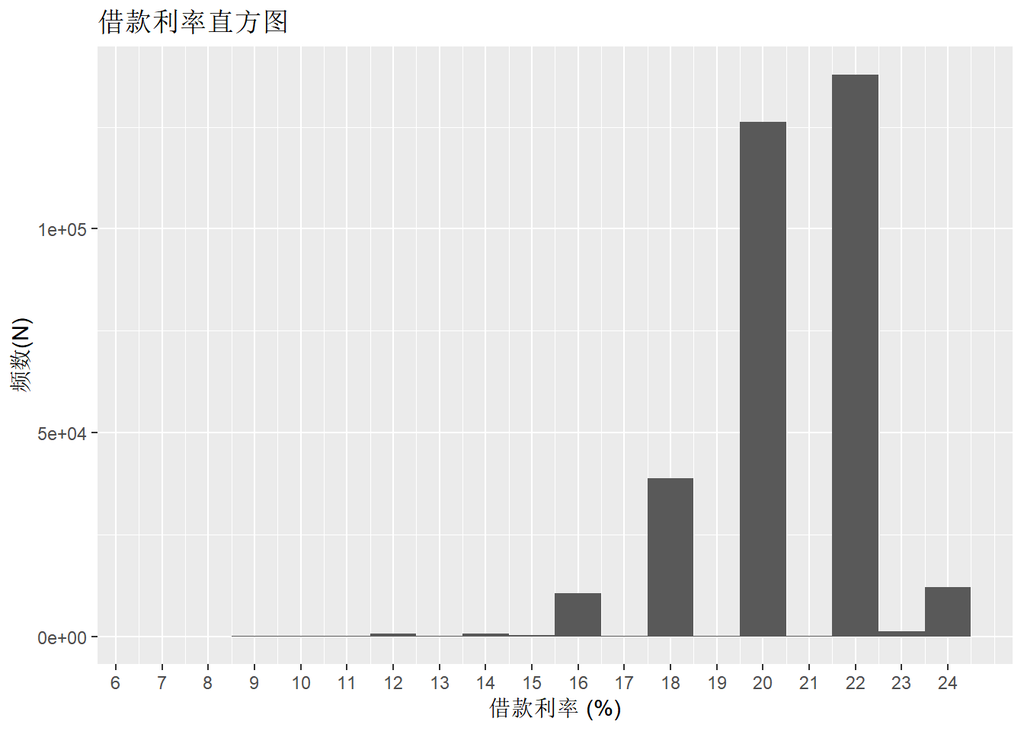

结论：借款利率最多的是20%和22%。

Plot Two

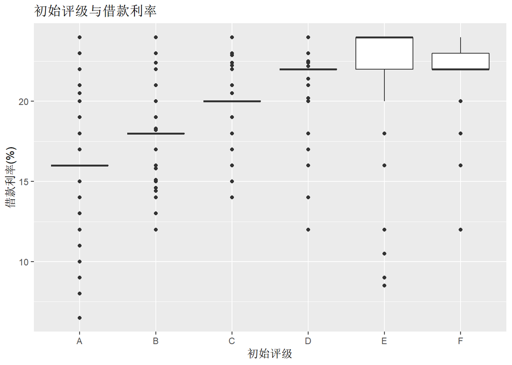

结论：初始评级越高，借款利率越低。

Plot Three

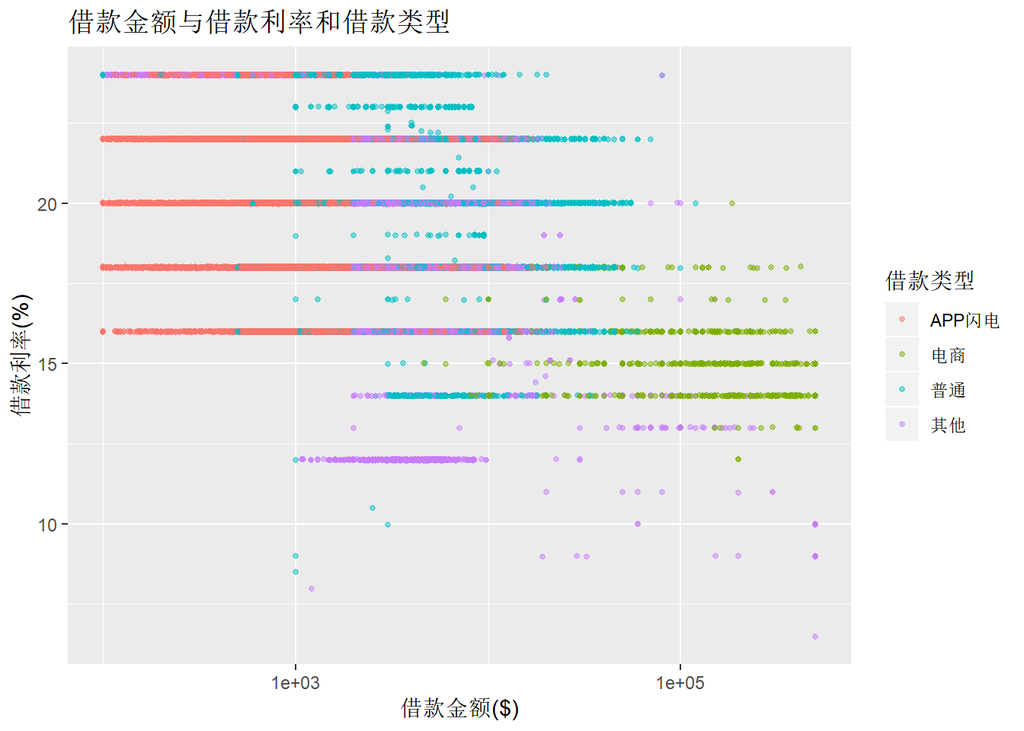

结论：APP闪电的借款金额较少，但借款利率较高；电商的借款金额较多，借款利率较低；普通的借款金额处于中等水平，借款利率也较高，但小于APP闪电的借款利率；其他类型借款金额和借款利率分布比较广泛。

# 总结与反思

### 总结：

#### 借款利率集中在18%~24%，其中利率为20%和22%的信用标数量最多。借款利率与初始评级，借款金额，借款类型关系最密切。初始评级越高、借款金额越多，则借款利率越低。APP闪电的借款利率最高，电商的借款利率最低，其他类型和普通的借款利率分布较广泛。

### 反思：

#### 1.尽可能将所有变量与借款利率的关系都讨论了。因为有些变量是非首标才存在的，为了讨论非首标数据特有的变量对借款利率的影响，通过首标与非首标的数据分别建立了模型。

#### 2.想知道认证方式与借款利率的关系，但是认证方式是用不同字段分开表示的，而且一种用户也不止一种认证方式。后期可以对数据进行整理后分析认证方式及其组合对借款利率的影响。

#### 3.借款期限最多的月份是6个月和12个月，6个月的借款利率相比于12个月的较低，后期应该再讨论借款期限对借款利率的影响。